# Comparing lyrics of Coldplay, Eminem, Drake

Dipankar Lahiri

12/11/2024

This is a word frequency analysis using parts-of-speech tagging of the entire lyrics of three popular music artists - Coldplay, Eminem and Drake. The differences in the lyrics highlight the contrasting approaches to songwriting in alternative rock and rap/hip-hop.

## Highlights of Findings

**1. Favourite Words and Themes**

Coldplay’s most common words are about emotions and abstract themes like ‘love’, ‘world’, ‘time’, ‘life’. Their verbs (‘feel’, ‘hear’, ‘wait’, ‘live’, ‘cry’) suggest introspection and emotional labour. Reflections on emotions, the temporality of experience and cosmic elements are some broad themes that can be identified from Coldplay’s most common words.

Drake and Eminem lean heavily on slang and explicit language. Their top words include nigga, shit, bitch, fuck, money, and baby — terms tied to rap’s linguistic identity. Drake’s favourite words are ‘nigga’, ‘shit’, ‘girl’, ‘time’, ‘love’, ‘fuck’, ‘money’, ‘baby’, ‘life’ and ‘bitch’. Eminem’s favourite words are ‘shit’, ‘fuck’, ‘bitch’, ‘time’, ‘shady’, ‘ass’, ‘day’, leave’, ‘feel’ and ‘girl’.

**2. Adjective Use**

‘Real’, ‘bad’ and ‘crazy’ are some common top adjectives between Drake and Eminem, though ‘real’ occurs many more times in Drake’s lyrics and ‘bad’ occurs many more times in Eminem’s.

**3. Verb Use**

Top verbs are more common across all artists. ‘Feel’, ‘hear’ and ‘start’ are three high-occuring verbs common between all three artists.

‘Play’ is a verb commonly used by Drake only, ‘fuck’ and ‘kill’ are verbs commonly used by Eminem only.

## Coldplay’s Top Words

**Verbs -** feel, hear, wait, be, live, fly, talk, start, cry, stand

```
## $Verbs
##    upos lemma   n
## 1  VERB  feel 101
## 2  VERB  hear  99
## 3  VERB  wait  90
## 4  VERB    be  63
## 5  VERB    se  55
## 6  VERB singe  50
## 7  VERB  live  48
## 8  VERB   fly  45
## 9  VERB  talk  43
## 10 VERB start  42
## 11 VERB   cry  38
## 12 VERB stand  38
## 13 VERB  find  36
## 14 VERB  stop  35
## 15 VERB  stay  33
```

**Nouns -** love, world, time, day, life, light, sky, head, heart, sun

```
## $Nouns
##    upos  lemma   n
## 1  NOUN   love 218
## 2  NOUN  chris 145
## 3  NOUN  gonna 133
## 4  NOUN martin 130
## 5  NOUN  world 127
## 6  NOUN   time 112
## 7  NOUN    day 107
## 8  NOUN   life  94
## 9  NOUN  light  89
## 10 NOUN  wanna  84
## 11 NOUN  cause  79
## 12 NOUN    sky  77
## 13 NOUN   head  76
## 14 NOUN  heart  73
## 15 NOUN    sun  69
```

**Adjectives -** close, wrong, true, alright, careful, dark, cold, strong, beautiful, free

```
## $Adjectives
##    upos     lemma  n
## 1   ADJ      lose 68
## 2   ADJ     close 36
## 3   ADJ     wrong 33
## 4   ADJ      true 31
## 5   ADJ   alright 27
## 6   ADJ   careful 24
## 7   ADJ      dark 23
## 8   ADJ      cold 21
## 9   ADJ     drink 20
## 10  ADJ    strong 19
## 11  ADJ beautiful 18
## 12  ADJ      free 17
## 13  ADJ        re 17
## 14  ADJ     alive 16
## 15  ADJ   hardest 16
```

**Adverbs -** forever, inside, here, all, slowly, underneath, pretty, where

```
## $Adverbs
##    upos      lemma  n
## 1   ADV       home 44
## 2   ADV    forever 26
## 3   ADV     inside 16
## 4   ADV      round 15
## 5   ADV       loud 12
## 6   ADV       here 11
## 7   ADV        all  9
## 8   ADV     slowly  9
## 9   ADV underneath  8
## 10  ADV         en  7
## 11  ADV  superhero  7
## 12  ADV      doubt  6
## 13  ADV     pretty  6
## 14  ADV      where  6
## 15  ADV      alien  5
```

**Top Overall Words -** love (218), world (127), time (112), day (107), feel (101)

### Top Themes

- ‘Love’ is the most common word. ‘Feel’ is the only non-noun word to occur more than 100 times. ‘Life’ and ‘Heart’ are other top words that can be said to fall under a broad theme of emotional reflection.
- ‘Time’ and ‘Day’, two of the other top 5 words overall, these can be seen to represent a theme of temporality. ‘Forever’, the most used adverb, ‘Wait’ and ‘Start’ fall under this theme.
- ‘World’, the second most common word overall, represents a theme of the cosmos. This includes natural elements like ‘Light’, ‘Sky’ and ‘Sun’.

## Drake’s Top Words

```
## $Verbs
##    upos lemma   n
## 1  VERB  feel 259
## 2  VERB start 240
## 3  VERB leave 233
## 4  VERB  hear 200
## 5  VERB  talk 195
## 6  VERB  stay 185
## 7  VERB  tell 181
## 8  VERB  play 160
## 9  VERB   hit 159
## 10 VERB    be 142
## 11 VERB guess 140
## 12 VERB  live 132
## 13 VERB bring 130
## 14 VERB watch 130
## 15 VERB  stop 114
```

```
## $Nouns
##    upos lemma    n
## 1  NOUN nigga 1105
## 2  NOUN drake  924
## 3  NOUN  shit  799
## 4  NOUN  girl  777
## 5  NOUN  time  565
## 6  NOUN  love  560
## 7  NOUN wanna  429
## 8  NOUN  fuck  402
## 9  NOUN money  389
## 10 NOUN  baby  359
## 11 NOUN cause  346
## 12 NOUN gotta  335
## 13 NOUN  life  279
## 14 NOUN bitch  273
## 15 NOUN  city  261
```

```
## $Adjectives
##    upos lemma   n
## 1   ADJ  real 268
## 2   ADJ  hard 147
## 3   ADJ   bad 124
## 4   ADJ   top  96
## 5   ADJ ready  93
## 6   ADJ wrong  88
## 7   ADJ  nice  73
## 8   ADJ crazy  71
## 9   ADJ  late  69
## 10  ADJ black  64
## 11  ADJ  past  60
## 12  ADJ   hot  59
## 13  ADJ  free  58
## 14  ADJ  slow  57
## 15  ADJ   low  56
```

```
## $Adverbs
##    upos    lemma   n
## 1   ADV     home 142
## 2   ADV     damn 131
## 3   ADV  forever  64
## 4   ADV straight  52
## 5   ADV   inside  50
## 6   ADV nowadays  37
## 7   ADV     fore  30
## 8   ADV    ahead  28
## 9   ADV  anymore  28
## 10  ADV  finally  28
## 11  ADV    kinda  28
## 12  ADV    brand  22
## 13  ADV probably  22
## 14  ADV    round  22
## 15  ADV    doubt  21
```

**Drake’s Top Words -** Nigga, Shit, Girl, Time, Love, Fuck, Money, Baby, Life, Bitch (all nouns)

**Drake’s Top Non-Noun Words -** Real (ADJECTIVE - 268), Feel (VERB - 259), Start (VERB - 240), Leave (VERB - 233), Hear (Verb - 200)

## Eminem

```
## $Verbs
##    upos lemma   n
## 1  VERB leave 414
## 2  VERB  feel 407
## 3  VERB  fuck 319
## 4  VERB  hear 309
## 5  VERB start 308
## 6  VERB   hit 301
## 7  VERB  kill 266
## 8  VERB    be 260
## 9  VERB  stop 246
## 10 VERB  beat 239
## 11 VERB   die 231
## 12 VERB  blow 214
## 13 VERB  tell 197
## 14 VERB   let 192
## 15 VERB  walk 187
```

```
## $Nouns
##    upos   lemma    n
## 1  NOUN    shit 1175
## 2  NOUN   cause 1011
## 3  NOUN    fuck  985
## 4  NOUN   bitch  791
## 5  NOUN    time  665
## 6  NOUN   th'ey  636
## 7  NOUN   shady  535
## 8  NOUN fucking  529
## 9  NOUN   wanna  521
## 10 NOUN   gonna  447
## 11 NOUN     ass  434
## 12 NOUN     day  425
## 13 NOUN    girl  363
## 14 NOUN    love  345
## 15 NOUN    call  324
```

```
## $Adjectives
##    upos lemma   n
## 1   ADJ   bad 231
## 2   ADJ white 216
## 3   ADJ   mic 202
## 4   ADJ crazy 190
## 5   ADJ  real 185
## 6   ADJ  sick 159
## 7   ADJ black 137
## 8   ADJ  dead 122
## 9   ADJ   mad 122
## 10  ADJ   top 111
## 11  ADJ front 107
## 12  ADJ  hard 100
## 13  ADJ close  94
## 14  ADJ  cold  94
## 15  ADJ wrong  87
```

```
## $Adverbs
##    upos          lemma   n
## 1   ADV           damn 193
## 2   ADV           home 151
## 3   ADV         inside 138
## 4   ADV       straight  93
## 5   ADV           fore  66
## 6   ADV           here  63
## 7   ADV uncontrollably  61
## 8   ADV         pretty  54
## 9   ADV          loose  50
## 10  ADV          smack  45
## 11  ADV          kinda  44
## 12  ADV          where  41
## 13  ADV           loud  35
## 14  ADV        finally  30
## 15  ADV       mentally  30
```

**Eminem’s Top Words -** Shit, Fuck, Bitch, Time, Shady, Ass, Day, Leave (Verb), Feel (Verb), Girl

## Visualisations

[figure not shown]

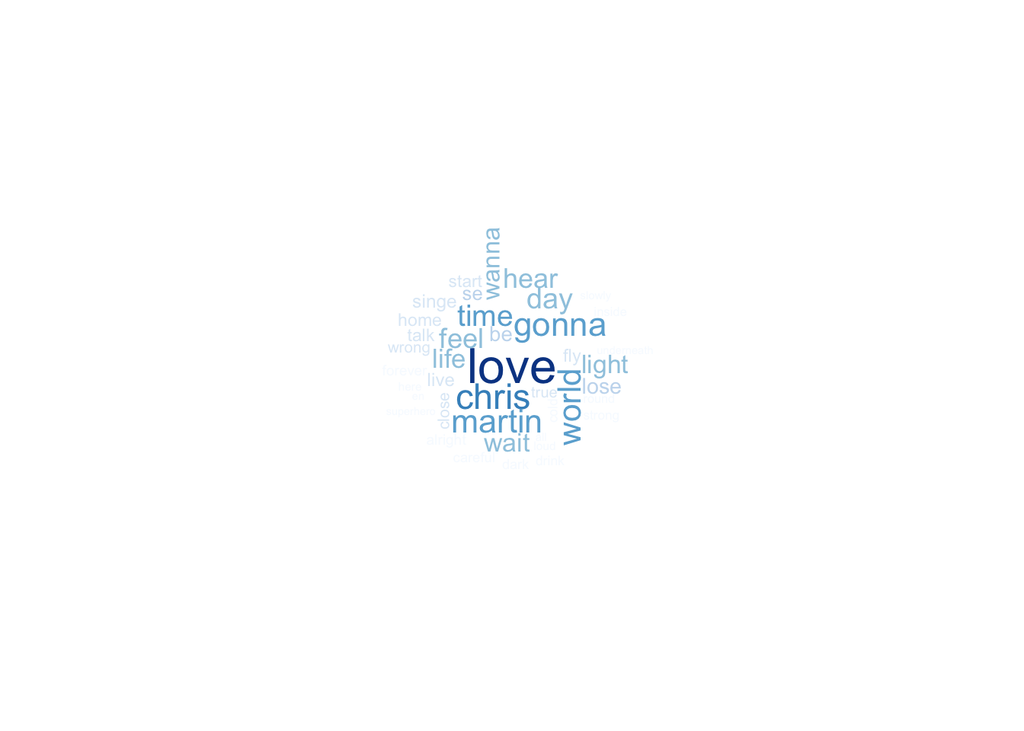

```r
plot_wordcloud("Coldplay", "Blues")
```

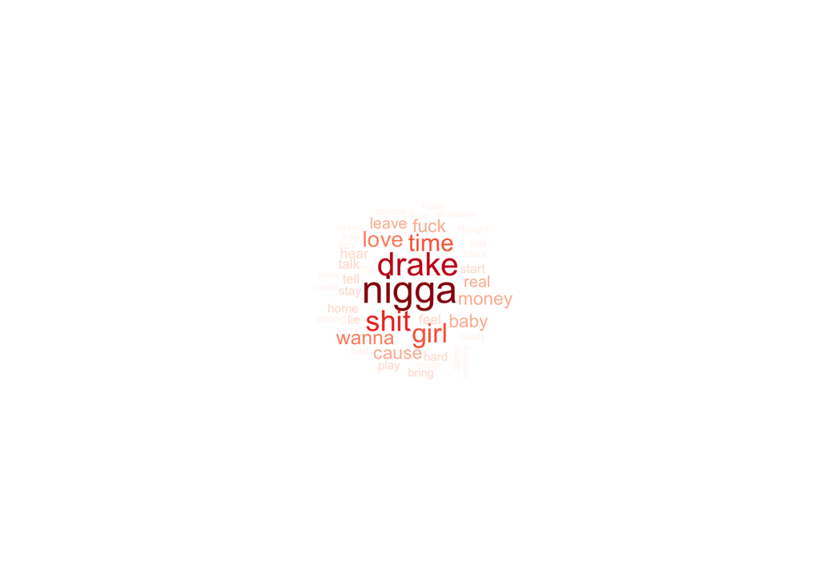

```r
plot_wordcloud("Drake", "Reds")
```

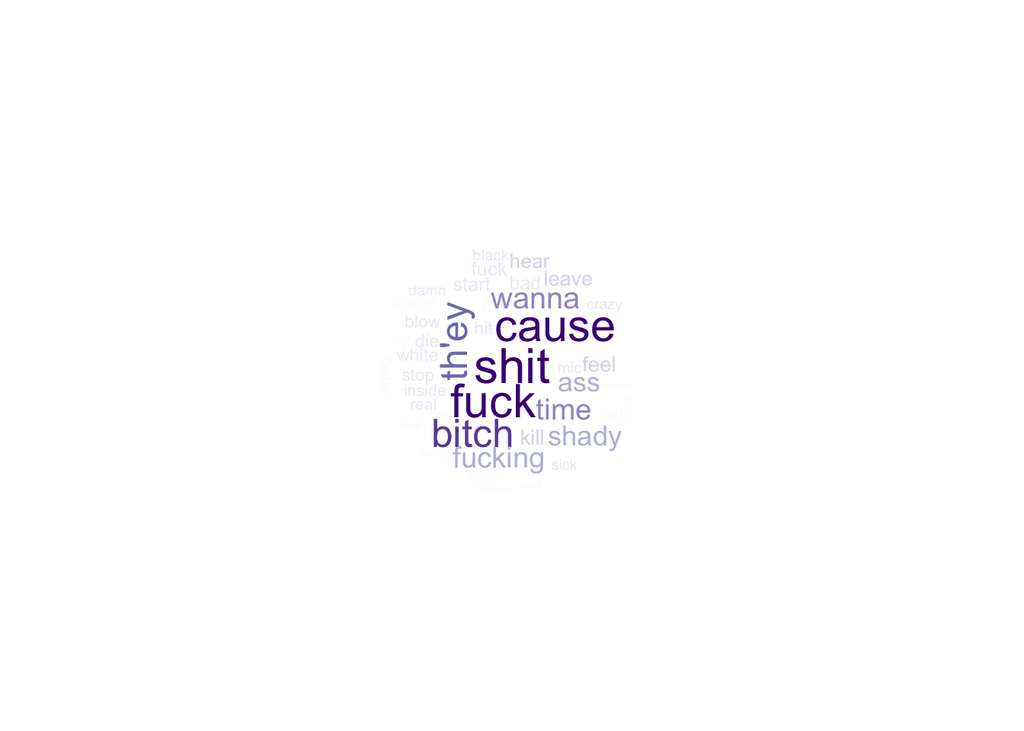

```r
plot_wordcloud("Eminem", "Purples")
```